# COMBINED-DATA WRANGLING—SUBMISSION 1006

ANONYMIZED

2025-02-24

*This notebook contains code to combine data from Study 0, Study 1, Study 2, and Study 3 of the MAGIC-VIS project to a single single normalized dataset of (valid) participant responses.*

**NOTE** This file can only be executed *after* the study specific wrangling files have been run, as those notebooks transform the data from raw qualtrics format to a standardized format.

## 0.1 IMPORT Configuration Files

*Import files with reference information for stimuli `ref_stimuli` and qualtrics surveys `ref_surveys`.*

```r
############## IMPORT STIMULI FILE
#contains data for each stimulus used
ref_stimuli <- read_csv("data/input/REFERENCE/stimuli.csv", col_names = TRUE) %>%
  mutate(
    BLOCK = as.factor(BLOCK),
    STIMULUS_CATEGORY = as.factor(CATEGORY),
    ID = as.factor(ID),
    MAKER_ID = as.factor(MAKER_ID)) %>%
  select(-CATEGORY)



############## STUDY ID FILE
#most blocks were run as separate qualtrics surveys with diffferent recruitments in Prolific
ref_surveys <- read_csv("data/input/REFERENCE/studies.csv", col_names = TRUE) %>%
  mutate(
    ID.Study = as.factor(ID.Study),
    Assigned.Block = as.factor(Assigned.Block),
    Distribution = as.factor(Distribution),
    Prolific.Name = as.factor(Prolific.Name),
    Qualtrics.URL = as.factor(Qualtrics.URL),
    Qualtrics.Survey = as.factor(Qualtrics.Survey),
    Sample = as.factor(Sample),
    Study = as.factor(Study)
)
```

## 0.2 DEFINE Labels

*Define labels used in survey questions and response options; used to generate labels for graphs and filtering of datasets in analysis files.*

```r
############## BUILD LABELS
ref_stim_id <- levels(ref_stimuli$ID)

### SD questions on Studies S1, S2
ref_sd_questions <- c("MAKER_DESIGN","MAKER_DATA",
                      "MAKER_POLITIC", "MAKER_ARGUE","MAKER_SELF","MAKER_ALIGN","MAKER_TRUST",
                      "CHART_TRUST", "CHART_INTENT", "CHART_LIKE", "CHART_BEAUTY")
ref_sd_questions_z <- c("MAKER_DESIGN_z","MAKER_DATA_z",
                      "MAKER_POLITIC_z", "MAKER_ARGUE_z","MAKER_SELF_z","MAKER_ALIGN_z","MAKER_TRUST_z",
                      "CHART_TRUST_z", "CHART_INTENT_z", "CHART_LIKE_z", "CHART_BEAUTY_z")
ref_conf_questions <- c("MAKER_CONF","AGE_CONF","GENDER_CONF")
## SD questions on Study3
ref_min_sd_questions <-  c("DESIGN","DATA","POLITICS","ALIGN","INTENT","TRUST","BEAUTY")
ref_min_sd_questions_z <-  c("DESIGN_z","DATA_z","POLITICS_z", "ALIGN_z","INTENT_z","TRUST_z","BEAUTY_z")
ref_min_conf_questions <- c("ID_CONF","AGE_CONF","GENDER_CONF")


### USEFUL CODE FOR TROUBLESHOOTING COMPARING DF STRUCTURE
#dataframe column comparisons
# x <- janitor::compare_df_cols(df1, df3)
```

## 0.3 IMPORT Wrangled Data

```r
## IMPORT STUDIES 1-3 FILES
df_participants_s12 <- readRDS("data/output/Study_1_2/df_participants.rds")
df_graphs_s12 <- readRDS("data/output/Study_1_2/df_graphs_z.rds") #zscore version has both raw and zscores
df_questions_long_s12 <- readRDS("data/output/Study_1_2/df_questions_long.rds") #all qs long
df_sd_questions_long_s12 <- readRDS("data/output/Study_1_2/df_sd_questions_long.rds")
df_sd_questions_long_s12_z <- readRDS("data/output/Study_1_2/df_sd_questions_long_z.rds")


## IMPORT Study 3 FILES
df_participants_s3 <- readRDS("data/output/Study_3/df_participants_S3.rds")
df_graphs_s3 <- readRDS("data/output/Study_3/df_graphs_z_S3.rds") #zscore version has both raw and zscores
df_questions_long_s3 <- readRDS("data/output/Study_3/df_questions_long_S3.rds")
df_sd_questions_long_s3 <- readRDS("data/output/Study_3/df_sd_questions_long_S3.rds")
df_sd_questions_long_s3_z <- readRDS("data/output/Study_3/df_sd_questions_long_z_S3.rds")
```

## 0.4 JOIN PARTICIPANT level files

```r
## ASSIGN DFS
df1 <- df_participants_s12
df3 <- df_participants_s3

#dataframe column comparisons
# x <- janitor::compare_df_cols(df1, df3)
#x

## JOIN DFS
df <- rbind(df1,df3)


## PRINT
print("PARTICIPANTS BY STUDY AND BLOCK")
```

```
## [1] "PARTICIPANTS BY STUDY AND BLOCK"
```

```r
addmargins(table(df$Study, df$Assigned.Block))
```

```
##
##            1   2   3   4   5   6 Sum
##   Study1  15  12  12  14  13  12  78
##   Study2  40  40  40  40  40  40 240
##   Study3  40   0   0   0   0   0  40
##   Study0  40   0   0   0   0   0  40
##   Sum    135  52  52  54  53  52 398
```

```r
## WRITE FILE
saveRDS(df, file = "data/output/COMBINED/df_participants_ALL.rds")

df_participants_all <- df
## CLEANUP
rm(df, df1, df3)
```

## 0.5 JOIN GRAPH level Files

```r
## WRANGLE STUDIES 1_3,
df1 <- df_graphs_s12 %>%
  # Retain only cols needed for modelling
  select(PID, Assigned.Block, Study, Sample, D_politicsSocial, D_politicsFiscal,
         STIMULUS_CATEGORY, STIMULUS, BLOCK, ENCOUNTER, MAKER_ID, MAKER_AGE, MAKER_GENDER,
         MAKER_CONF, AGE_CONF, GENDER_CONF,
         MAKER_DESIGN:CHART_TRUST,
         MAKER_CONF_z, AGE_CONF_z,GENDER_CONF_z,
         MAKER_DESIGN_z:CHART_TRUST_z
  ) %>%
  # Filter out questions dropped from Study 3
  select(-c("MAKER_ARGUE_z","MAKER_SELF_z","CHART_LIKE_z","CHART_TRUST_z"))  %>%
  select(-c("MAKER_ARGUE","MAKER_SELF","CHART_LIKE","CHART_TRUST","MAKER_LATENCY","TOOL_CONF")) %>%
  # Rename questions to match Study 3 and get rid of magicwizard transform for raw z value
  mutate(
    DESIGN_z = as.numeric(MAKER_DESIGN_z),
    DATA_z = as.numeric(MAKER_DATA_z),
    POLITICS_z = as.numeric(MAKER_POLITIC_z),
    ALIGN_z = as.numeric(MAKER_ALIGN_z),
    TRUST_z = as.numeric(MAKER_TRUST_z),
    BEAUTY_z = as.numeric(CHART_BEAUTY_z),
    INTENT_z = as.numeric(CHART_INTENT_z),
    MAKER_CONF_z = as.numeric(MAKER_CONF_z),
    AGE_CONF_z = as.numeric(AGE_CONF_z),
    GENDER_CONF_z = as.numeric(GENDER_CONF_z)
    ) %>%
  rename(
    ID = MAKER_ID,
    AGE = MAKER_AGE,
    GENDER = MAKER_GENDER,
    ID_CONF = MAKER_CONF,
    DESIGN = MAKER_DESIGN,
    DATA = MAKER_DATA,
    POLITICS = MAKER_POLITIC,
    ALIGN=MAKER_ALIGN,
    INTENT=CHART_INTENT,
    TRUST=MAKER_TRUST,
    BEAUTY=CHART_BEAUTY,
    ID_CONF_z = MAKER_CONF_z

  ) %>%
  # Drop old columns
  select(-c(MAKER_DESIGN_z:CHART_INTENT_z)) %>%
  mutate(TIME="PRE") %>% ## SET ALL STUDY 1,2 GRAPHS TO PRE B/C the obscured stimulus was presented
  # Drop levels
  droplevels()

## Study 3, RETAIN ONLY COLUMNS NECESSARY FOR MODELLING, and only TIME=PRE
df3_PRE <- df_graphs_s3%>%
  # Retail only cols needed for modelling
  select(PID, Assigned.Block, Study, Sample, D_politicsSocial, D_politicsFiscal,
        STIMULUS_CATEGORY, STIMULUS, BLOCK,
        # only keep pre-test columns
        contains("PRE")) %>%
  # drop latency
  select(-contains("LATENCY")) %>%
  # rename categoricals
  rename(
    ENCOUNTER = PRE_ENCOUNTER,
    ID = PRE_ID,
    AGE = PRE_AGE,
    GENDER = PRE_GENDER,
    DESIGN = PRE_DESIGN,
    DATA = PRE_DATA,
    POLITICS = PRE_POLITICS,
    ALIGN = PRE_ALIGN,
    INTENT = PRE_INTENT,
    TRUST = PRE_TRUST,
    BEAUTY = PRE_BEAUTY,
    ID_CONF = PRE_ID_CONF,
    AGE_CONF = PRE_AGE_CONF,
    GENDER_CONF = PRE_GENDER_CONF
  ) %>%
  #get rid of magicwizard transform for raw z value
  mutate(
    DESIGN_z = as.numeric(PRE_DESIGN_z),
    DATA_z = as.numeric(PRE_DATA_z),
    POLITICS_z = as.numeric(PRE_POLITICS_z),
    ALIGN_z = as.numeric(PRE_ALIGN_z),
    TRUST_z = as.numeric(PRE_TRUST_z),
    BEAUTY_z = as.numeric(PRE_BEAUTY_z),
    INTENT_z = as.numeric(PRE_INTENT_z),
    ID_CONF_z = as.numeric(PRE_ID_CONF_z),
    AGE_CONF_z = as.numeric(PRE_AGE_CONF_z),
    GENDER_CONF_z = as.numeric(PRE_GENDER_CONF_z)
    ) %>%
  # drop old columns datawizard columns
  select(-c(PRE_DESIGN_z: PRE_INTENT_z)) %>%
  select(-c(PRE_ID_CONF_z, PRE_AGE_CONF_z, PRE_GENDER_CONF_z)) %>%
  mutate(TIME = "PRE") %>%
  droplevels()


# Study 3, RETAIN ONLY COLUMNS NECESSARY FOR MODELLING, and only TIME=post
df3_POST <- df_graphs_s3%>%
  # Retail only cols needed for modelling
  select(PID, Assigned.Block, Study, Sample, D_politicsSocial, D_politicsFiscal,
        STIMULUS_CATEGORY, STIMULUS, BLOCK,
        # only keep pre-test columns
        contains("POST")) %>%
  # drop latency
  select(-contains("LATENCY")) %>%
  # rename categoricals
  rename(
    ENCOUNTER = POST_ENCOUNTER,
    ID = POST_ID,
    AGE = POST_AGE,
    GENDER = POST_GENDER,
    DESIGN = POST_DESIGN,
    DATA = POST_DATA,
    POLITICS = POST_POLITICS,
    ALIGN = POST_ALIGN,
    INTENT = POST_INTENT,
    TRUST = POST_TRUST,
    BEAUTY = POST_BEAUTY,
    ID_CONF = POST_ID_CONF,
    AGE_CONF = POST_AGE_CONF,
    GENDER_CONF = POST_GENDER_CONF
  ) %>%
  #get rid of magicwizard transform for raw z value
  mutate(
    DESIGN_z = as.numeric(POST_DESIGN_z),
    DATA_z = as.numeric(POST_DATA_z),
    POLITICS_z = as.numeric(POST_POLITICS_z),
    ALIGN_z = as.numeric(POST_ALIGN_z),
    TRUST_z = as.numeric(POST_TRUST_z),
    BEAUTY_z = as.numeric(POST_BEAUTY_z),
    INTENT_z = as.numeric(POST_INTENT_z),
    ID_CONF_z = as.numeric(POST_ID_CONF_z),
    AGE_CONF_z = as.numeric(POST_AGE_CONF_z),
    GENDER_CONF_z = as.numeric(POST_GENDER_CONF_z)
    ) %>%
  # drop old columns datawizard columns
  select(-c(POST_DESIGN_z: POST_INTENT_z)) %>%
  select(-c(POST_ID_CONF_z, POST_AGE_CONF_z, POST_GENDER_CONF_z)) %>%
  mutate(TIME="POST") %>%
  droplevels()




## JOIN STUDIES
df <- rbind(df1, df3_PRE, df3_POST)

## PRINT
print("PARTICIPANTS BY STUDY AND STIMULUS")
```

```
## [1] "PARTICIPANTS BY STUDY AND STIMULUS"
```

```r
addmargins(table(df$Study, df$STIMULUS))
```

```
##
##          B0-0 B1-1 B1-2 B1-3 B1-4 B2-1 B2-2 B2-3 B2-4 B3-1 B3-2 B3-3 B3-4 B4-1
##   Study1   78   15   15   15   15   12   12   12   12   12   12   12   12   14
##   Study2  240   40   40   40   40   40   40   40   40   40   40   40   40   40
##   Study0   40   40   40   40   40    0    0    0    0    0    0    0    0    0
##   Study3   80   80   80   80   80    0    0    0    0    0    0    0    0    0
##   Sum     438  175  175  175  175   52   52   52   52   52   52   52   52   54
##
##          B4-2 B4-3 B4-4 B5-1 B5-2 B5-3 B5-4 B6-1 B6-2 B6-3 B6-4  Sum
##   Study1   14   14   14   13   13   13   13   12   12   12   12  390
##   Study2   40   40   40   40   40   40   40   40   40   40   40 1200
##   Study0    0    0    0    0    0    0    0    0    0    0    0  200
##   Study3    0    0    0    0    0    0    0    0    0    0    0  400
##   Sum      54   54   54   53   53   53   53   52   52   52   52 2190
```

```r
## WRITE FILE
saveRDS(df, file = "data/output/COMBINED/df_graphs_ALL.rds")

df_graphs_all <- df
## CLEANUP
rm(df, df1, df3)
```

## 0.6 JOIN QUESTION LONG FILES

(useful for graphs and models that need all qs in long format, not just the sd questions)

```r
## KEEP TIME COLUMN FOR GRAPHING

## WRANGLE STUDIES 1_3,
df1 <- df_questions_long_s12 %>%
  # Retain only cols needed for modelling
  select(PID, Assigned.Block, Study, Sample, D_politicsSocial, D_politicsFiscal,
         STIMULUS_CATEGORY, STIMULUS, BLOCK, QUESTION, value) %>%
  # Filter out questions dropped from Study 3
  filter(QUESTION %nin% c("MAKER_ARGUE","MAKER_SELF","CHART_LIKE","CHART_TRUST")) %>%
  # Rename questions to match Study 3
  mutate(
    QUESTION = str_replace(QUESTION, "MAKER_CONF","ID_CONF"), #handle maker conf
    QUESTION = str_replace(QUESTION, "MAKER_",""), #strip MAKER_ prefix
    QUESTION = str_replace(QUESTION, "CHART_",""), #strip CHART_ prefix
    QUESTION = str_replace(QUESTION, "POLITIC","POLITICS"),
    TIME = "PRE" #INDICATES measuremeent was on obscured graph
  ) %>%
  # Drop levels
  droplevels()

## Study 3, RETAIN ONLY COLUMNS NECESSARY FOR MODELLING, and only TIME=PRE
df3 <- df_questions_long_s3 %>%
  #Retail only cols needed for modelling
  select(PID, Assigned.Block, Study, Sample, D_politicsSocial, D_politicsFiscal,
        STIMULUS_CATEGORY, STIMULUS, BLOCK, QUESTION, value, TIME) %>%
  ######### OLD CODE
  # # Filter out responses from the POST test
  # filter(TIME=="PRE") %>%
  # # Drop time
  # select(-TIME) %>%
  # Drop levels
  droplevels()

## JOIN STUDIES
df <- rbind(df1, df3) %>%
  mutate(TIME=factor(TIME)) %>%
  #drop questions we don't use
  filter(QUESTION %nin% c("DETAIL","EXPLAIN","LATENCY","TOOL_ID","TOOL_CONF","TOOL_DETAIL","TYPE","ACTION"))


## PRINT
print("PARTICIPANT-QUESTSIONS BY STUDY AND STIMULUS AND time")
```

```
## [1] "PARTICIPANT-QUESTSIONS BY STUDY AND STIMULUS AND time"
```

```r
addmargins(table(df$QUESTION, df$STIMULUS, df$Study))
```

```
## , ,  = Study1
##
##
##                B0-0  B1-1  B1-2  B1-3  B1-4  B2-1  B2-2  B2-3  B2-4  B3-1  B3-2
##   AGE            78    15    15    15    15    12    12    12    12    12    12
##   AGE_CONF       78    15    15    15    15    12    12    12    12    12    12
##   ALIGN          78    15    15    15    15    12    12    12    12    12    12
##   BEAUTY         78    15    15    15    15    12    12    12    12    12    12
##   DATA           78    15    15    15    15    12    12    12    12    12    12
##   DESIGN         78    15    15    15    15    12    12    12    12    12    12
##   ENCOUNTER      78    15    15    15    15    12    12    12    12    12    12
##   GENDER         78    15    15    15    15    12    12    12    12    12    12
##   GENDER_CONF    78    15    15    15    15    12    12    12    12    12    12
##   ID             78    15    15    15    15    12    12    12    12    12    12
##   ID_CONF        78    15    15    15    15    12    12    12    12    12    12
##   INTENT         78    15    15    15    15    12    12    12    12    12    12
##   POLITICS       78    15    15    15    15    12    12    12    12    12    12
##   TRUST          78    15    15    15    15    12    12    12    12    12    12
##   Sum          1092   210   210   210   210   168   168   168   168   168   168
##
##                B3-3  B3-4  B4-1  B4-2  B4-3  B4-4  B5-1  B5-2  B5-3  B5-4  B6-1
##   AGE            12    12    14    14    14    14    13    13    13    13    12
##   AGE_CONF       12    12    14    14    14    14    13    13    13    13    12
##   ALIGN          12    12    14    14    14    14    13    13    13    13    12
##   BEAUTY         12    12    14    14    14    14    13    13    13    13    12
##   DATA           12    12    14    14    14    14    13    13    13    13    12
##   DESIGN         12    12    14    14    14    14    13    13    13    13    12
##   ENCOUNTER      12    12    14    14    14    14    13    13    13    13    12
##   GENDER         12    12    14    14    14    14    13    13    13    13    12
##   GENDER_CONF    12    12    14    14    14    14    13    13    13    13    12
##   ID             12    12    14    14    14    14    13    13    13    13    12
##   ID_CONF        12    12    14    14    14    14    13    13    13    13    12
##   INTENT         12    12    14    14    14    14    13    13    13    13    12
##   POLITICS       12    12    14    14    14    14    13    13    13    13    12
##   TRUST          12    12    14    14    14    14    13    13    13    13    12
##   Sum           168   168   196   196   196   196   182   182   182   182   168
##
##                B6-2  B6-3  B6-4   Sum
##   AGE            12    12    12   390
##   AGE_CONF       12    12    12   390
```

[output cut: 214 more lines]

```
##   AGE            52    52    52  2190
##   AGE_CONF       52    52    52  2190
##   ALIGN          52    52    52  2190
##   BEAUTY         52    52    52  2190
##   DATA           52    52    52  2190
##   DESIGN         52    52    52  2190
##   ENCOUNTER      52    52    52  2190
##   GENDER         52    52    52  2190
##   GENDER_CONF    52    52    52  2190
##   ID             52    52    52  2190
##   ID_CONF        52    52    52  2190
##   INTENT         52    52    52  2190
##   POLITICS       52    52    52  2190
##   TRUST          52    52    52  2190
##   Sum           728   728   728 30660
```

```r
table(df$Study, df$STIMULUS, df$TIME)
```

```
## , ,  = POST
##
##
##          B0-0 B1-1 B1-2 B1-3 B1-4 B2-1 B2-2 B2-3 B2-4 B3-1 B3-2 B3-3 B3-4 B4-1
##   Study1    0    0    0    0    0    0    0    0    0    0    0    0    0    0
##   Study2    0    0    0    0    0    0    0    0    0    0    0    0    0    0
##   Study0    0    0    0    0    0    0    0    0    0    0    0    0    0    0
##   Study3  560  560  560  560  560    0    0    0    0    0    0    0    0    0
##
##          B4-2 B4-3 B4-4 B5-1 B5-2 B5-3 B5-4 B6-1 B6-2 B6-3 B6-4
##   Study1    0    0    0    0    0    0    0    0    0    0    0
##   Study2    0    0    0    0    0    0    0    0    0    0    0
##   Study0    0    0    0    0    0    0    0    0    0    0    0
##   Study3    0    0    0    0    0    0    0    0    0    0    0
##
## , ,  = PRE
##
##
##          B0-0 B1-1 B1-2 B1-3 B1-4 B2-1 B2-2 B2-3 B2-4 B3-1 B3-2 B3-3 B3-4 B4-1
##   Study1 1092  210  210  210  210  168  168  168  168  168  168  168  168  196
##   Study2 3360  560  560  560  560  560  560  560  560  560  560  560  560  560
##   Study0  560  560  560  560  560    0    0    0    0    0    0    0    0    0
##   Study3  560  560  560  560  560    0    0    0    0    0    0    0    0    0
##
##          B4-2 B4-3 B4-4 B5-1 B5-2 B5-3 B5-4 B6-1 B6-2 B6-3 B6-4
##   Study1  196  196  196  182  182  182  182  168  168  168  168
##   Study2  560  560  560  560  560  560  560  560  560  560  560
##   Study0    0    0    0    0    0    0    0    0    0    0    0
##   Study3    0    0    0    0    0    0    0    0    0    0    0
```

```r
## WRITE FILE
saveRDS(df, file = "data/output/COMBINED/df_questions_long_ALL.rds")

## CLEANUP
rm(df, df1, df3)
```

## 0.7 JOIN SD QUESTION LONG Files

```r
## KEEP TIME COLUMN FOR GRAPHING

## WRANGLE STUDIES 1_3,
df1 <- df_sd_questions_long_s12 %>%
  # Retain only cols needed for modelling
  select(PID, Assigned.Block, Study, Sample, D_politicsSocial, D_politicsFiscal,
         STIMULUS_CATEGORY, STIMULUS, BLOCK, QUESTION, value) %>%
  # Filter out questions dropped from Study 3
  filter(QUESTION %nin% c("MAKER_ARGUE","MAKER_SELF","CHART_LIKE","CHART_TRUST")) %>%
  # Rename questions to match Study 3
  mutate(
    QUESTION = str_replace(QUESTION, "MAKER_",""), #strip MAKER_ prefix
    QUESTION = str_replace(QUESTION, "CHART_",""), #strip CHART_ prefix
    QUESTION = str_replace(QUESTION, "POLITIC","POLITICS"),
    QUESTION = factor(QUESTION, levels = ref_min_sd_questions), #set factor order
    TIME = "PRE" #INDICATES measuremeent was on obscured graph
  ) %>%
  # Drop levels
  droplevels()

## Study 3, RETAIN ONLY COLUMNS NECESSARY FOR MODELLING, and only TIME=PRE
df3 <- df_sd_questions_long_s3 %>%
  #Retail only cols needed for modelling
  select(PID, Assigned.Block, Study, Sample, D_politicsSocial, D_politicsFiscal,
        STIMULUS_CATEGORY, STIMULUS, BLOCK, QUESTION, value, TIME) %>%
  ######### OLD CODE
  # # Filter out responses from the POST test
  # filter(TIME=="PRE") %>%
  # # Drop time
  # select(-TIME) %>%
  # Drop levels
  droplevels()

## JOIN STUDIES
df <- rbind(df1, df3) %>%
  mutate(TIME=factor(TIME))


## PRINT
print("PARTICIPANT-QUESTSIONS BY STUDY AND STIMULUS AND time")
```

```
## [1] "PARTICIPANT-QUESTSIONS BY STUDY AND STIMULUS AND time"
```

```r
addmargins(table(df$QUESTION, df$STIMULUS, df$Study))
```

```
## , ,  = Study1
##
##
##             B0-0  B1-1  B1-2  B1-3  B1-4  B2-1  B2-2  B2-3  B2-4  B3-1  B3-2
##   DESIGN      78    15    15    15    15    12    12    12    12    12    12
##   DATA        78    15    15    15    15    12    12    12    12    12    12
##   POLITICS    78    15    15    15    15    12    12    12    12    12    12
##   ALIGN       78    15    15    15    15    12    12    12    12    12    12
##   INTENT      78    15    15    15    15    12    12    12    12    12    12
##   TRUST       78    15    15    15    15    12    12    12    12    12    12
##   BEAUTY      78    15    15    15    15    12    12    12    12    12    12
##   Sum        546   105   105   105   105    84    84    84    84    84    84
##
##             B3-3  B3-4  B4-1  B4-2  B4-3  B4-4  B5-1  B5-2  B5-3  B5-4  B6-1
##   DESIGN      12    12    14    14    14    14    13    13    13    13    12
##   DATA        12    12    14    14    14    14    13    13    13    13    12
##   POLITICS    12    12    14    14    14    14    13    13    13    13    12
##   ALIGN       12    12    14    14    14    14    13    13    13    13    12
##   INTENT      12    12    14    14    14    14    13    13    13    13    12
##   TRUST       12    12    14    14    14    14    13    13    13    13    12
##   BEAUTY      12    12    14    14    14    14    13    13    13    13    12
##   Sum         84    84    98    98    98    98    91    91    91    91    84
##
##             B6-2  B6-3  B6-4   Sum
##   DESIGN      12    12    12   390
##   DATA        12    12    12   390
##   POLITICS    12    12    12   390
##   ALIGN       12    12    12   390
##   INTENT      12    12    12   390
##   TRUST       12    12    12   390
##   BEAUTY      12    12    12   390
##   Sum         84    84    84  2730
##
## , ,  = Study2
##
##
##             B0-0  B1-1  B1-2  B1-3  B1-4  B2-1  B2-2  B2-3  B2-4  B3-1  B3-2
##   DESIGN     240    40    40    40    40    40    40    40    40    40    40
##   DATA       240    40    40    40    40    40    40    40    40    40    40
##   POLITICS   240    40    40    40    40    40    40    40    40    40    40
```

[output cut: 109 more lines]

```
##   ALIGN       52    52    54    54    54    54    53    53    53    53    52
##   INTENT      52    52    54    54    54    54    53    53    53    53    52
##   TRUST       52    52    54    54    54    54    53    53    53    53    52
##   BEAUTY      52    52    54    54    54    54    53    53    53    53    52
##   Sum        364   364   378   378   378   378   371   371   371   371   364
##
##             B6-2  B6-3  B6-4   Sum
##   DESIGN      52    52    52  2190
##   DATA        52    52    52  2190
##   POLITICS    52    52    52  2190
##   ALIGN       52    52    52  2190
##   INTENT      52    52    52  2190
##   TRUST       52    52    52  2190
##   BEAUTY      52    52    52  2190
##   Sum        364   364   364 15330
```

```r
table(df$Study, df$STIMULUS, df$TIME)
```

```
## , ,  = POST
##
##
##          B0-0 B1-1 B1-2 B1-3 B1-4 B2-1 B2-2 B2-3 B2-4 B3-1 B3-2 B3-3 B3-4 B4-1
##   Study1    0    0    0    0    0    0    0    0    0    0    0    0    0    0
##   Study2    0    0    0    0    0    0    0    0    0    0    0    0    0    0
##   Study0    0    0    0    0    0    0    0    0    0    0    0    0    0    0
##   Study3  280  280  280  280  280    0    0    0    0    0    0    0    0    0
##
##          B4-2 B4-3 B4-4 B5-1 B5-2 B5-3 B5-4 B6-1 B6-2 B6-3 B6-4
##   Study1    0    0    0    0    0    0    0    0    0    0    0
##   Study2    0    0    0    0    0    0    0    0    0    0    0
##   Study0    0    0    0    0    0    0    0    0    0    0    0
##   Study3    0    0    0    0    0    0    0    0    0    0    0
##
## , ,  = PRE
##
##
##          B0-0 B1-1 B1-2 B1-3 B1-4 B2-1 B2-2 B2-3 B2-4 B3-1 B3-2 B3-3 B3-4 B4-1
##   Study1  546  105  105  105  105   84   84   84   84   84   84   84   84   98
##   Study2 1680  280  280  280  280  280  280  280  280  280  280  280  280  280
##   Study0  280  280  280  280  280    0    0    0    0    0    0    0    0    0
##   Study3  280  280  280  280  280    0    0    0    0    0    0    0    0    0
##
##          B4-2 B4-3 B4-4 B5-1 B5-2 B5-3 B5-4 B6-1 B6-2 B6-3 B6-4
##   Study1   98   98   98   91   91   91   91   84   84   84   84
##   Study2  280  280  280  280  280  280  280  280  280  280  280
##   Study0    0    0    0    0    0    0    0    0    0    0    0
##   Study3    0    0    0    0    0    0    0    0    0    0    0
```

```r
## WRITE FILE
saveRDS(df, file = "data/output/COMBINED/df_sd_questions_long_ALL.rds")

## CLEANUP
rm(df, df1, df3)
```

## 0.8 JOIN SD QUESTION LONG Files (Z-SCORED)

```r
## WRANGLE STUDIES 1_3,
df1 <- df_sd_questions_long_s12_z %>%
  # Retain only cols needed for modelling
  select(PID, Assigned.Block, Study, Sample, D_politicsSocial, D_politicsFiscal,
         STIMULUS_CATEGORY, STIMULUS, BLOCK, QUESTION, value) %>%
  # Filter out questions dropped from Study 3
  filter(QUESTION %nin% c("MAKER_ARGUE_z","MAKER_SELF_z","CHART_LIKE_z","CHART_TRUST_z"))  %>%
  # Rename questions to match Study 3
  mutate(
    QUESTION = str_replace(QUESTION, "MAKER_",""), #strip MAKER_ prefix
    QUESTION = str_replace(QUESTION, "CHART_",""), #strip CHART_ prefix
    QUESTION = str_replace(QUESTION, "POLITIC","POLITICS"),
    QUESTION = factor(QUESTION, levels = ref_min_sd_questions_z), #set factor order
    TIME = "PRE"
    ) %>%
  # Drop levels
  droplevels()

## STUDY 3, RETAIN ONLY COLUMNS NECESSARY FOR MODELLING, and only TIME=PRE
df3 <- df_sd_questions_long_s3_z %>%
  #Retail only cols needed for modelling
  select(PID, Assigned.Block, Study, Sample, D_politicsSocial, D_politicsFiscal,
        STIMULUS_CATEGORY, STIMULUS, BLOCK, QUESTION, value, TIME) %>%
  # # Filter out responses from the POST test
  # filter(TIME=="PRE") %>%
  # # Drop time
  # select(-TIME) %>%
  # Drop levels
  droplevels()

## JOIN STUDIES
df <- rbind(df1, df3) %>%
  mutate(TIME=factor(TIME))

## PRINT
print("PARTICIPANT-QUESTSIONS BY STUDY AND STIMULUS")
```

```
## [1] "PARTICIPANT-QUESTSIONS BY STUDY AND STIMULUS"
```

```r
addmargins(table(df$QUESTION, df$STIMULUS, df$Study))
```

```
## , ,  = Study1
##
##
##               B0-0  B1-1  B1-2  B1-3  B1-4  B2-1  B2-2  B2-3  B2-4  B3-1  B3-2
##   DESIGN_z      78    15    15    15    15    12    12    12    12    12    12
##   DATA_z        78    15    15    15    15    12    12    12    12    12    12
##   POLITICS_z    78    15    15    15    15    12    12    12    12    12    12
##   ALIGN_z       78    15    15    15    15    12    12    12    12    12    12
##   INTENT_z      78    15    15    15    15    12    12    12    12    12    12
##   TRUST_z       78    15    15    15    15    12    12    12    12    12    12
##   BEAUTY_z      78    15    15    15    15    12    12    12    12    12    12
##   Sum          546   105   105   105   105    84    84    84    84    84    84
##
##               B3-3  B3-4  B4-1  B4-2  B4-3  B4-4  B5-1  B5-2  B5-3  B5-4  B6-1
##   DESIGN_z      12    12    14    14    14    14    13    13    13    13    12
##   DATA_z        12    12    14    14    14    14    13    13    13    13    12
##   POLITICS_z    12    12    14    14    14    14    13    13    13    13    12
##   ALIGN_z       12    12    14    14    14    14    13    13    13    13    12
##   INTENT_z      12    12    14    14    14    14    13    13    13    13    12
##   TRUST_z       12    12    14    14    14    14    13    13    13    13    12
##   BEAUTY_z      12    12    14    14    14    14    13    13    13    13    12
##   Sum           84    84    98    98    98    98    91    91    91    91    84
##
##               B6-2  B6-3  B6-4   Sum
##   DESIGN_z      12    12    12   390
##   DATA_z        12    12    12   390
##   POLITICS_z    12    12    12   390
##   ALIGN_z       12    12    12   390
##   INTENT_z      12    12    12   390
##   TRUST_z       12    12    12   390
##   BEAUTY_z      12    12    12   390
##   Sum           84    84    84  2730
##
## , ,  = Study2
##
##
##               B0-0  B1-1  B1-2  B1-3  B1-4  B2-1  B2-2  B2-3  B2-4  B3-1  B3-2
##   DESIGN_z     240    40    40    40    40    40    40    40    40    40    40
##   DATA_z       240    40    40    40    40    40    40    40    40    40    40
##   POLITICS_z   240    40    40    40    40    40    40    40    40    40    40
```

[output cut: 109 more lines]

```
##   ALIGN_z       52    52    54    54    54    54    53    53    53    53    52
##   INTENT_z      52    52    54    54    54    54    53    53    53    53    52
##   TRUST_z       52    52    54    54    54    54    53    53    53    53    52
##   BEAUTY_z      52    52    54    54    54    54    53    53    53    53    52
##   Sum          364   364   378   378   378   378   371   371   371   371   364
##
##               B6-2  B6-3  B6-4   Sum
##   DESIGN_z      52    52    52  2190
##   DATA_z        52    52    52  2190
##   POLITICS_z    52    52    52  2190
##   ALIGN_z       52    52    52  2190
##   INTENT_z      52    52    52  2190
##   TRUST_z       52    52    52  2190
##   BEAUTY_z      52    52    52  2190
##   Sum          364   364   364 15330
```

```r
table(df$Study, df$STIMULUS, df$TIME)
```

```
## , ,  = PRE
##
##
##          B0-0 B1-1 B1-2 B1-3 B1-4 B2-1 B2-2 B2-3 B2-4 B3-1 B3-2 B3-3 B3-4 B4-1
##   Study1  546  105  105  105  105   84   84   84   84   84   84   84   84   98
##   Study2 1680  280  280  280  280  280  280  280  280  280  280  280  280  280
##   Study0  280  280  280  280  280    0    0    0    0    0    0    0    0    0
##   Study3  560  560  560  560  560    0    0    0    0    0    0    0    0    0
##
##          B4-2 B4-3 B4-4 B5-1 B5-2 B5-3 B5-4 B6-1 B6-2 B6-3 B6-4
##   Study1   98   98   98   91   91   91   91   84   84   84   84
##   Study2  280  280  280  280  280  280  280  280  280  280  280
##   Study0    0    0    0    0    0    0    0    0    0    0    0
##   Study3    0    0    0    0    0    0    0    0    0    0    0
```

```r
## WRITE FILE
saveRDS(df, file = "data/output/COMBINED/df_sd_questions_long_ALL_z.rds")

#cleanup
rm(df1, df3, df)
```

# 1 PROFILING

## 1.1 PARTICIPANT-LEVEL

```r
dfSummary(df_participants_all,  #%>% select(PID, duration.min, Distribution, Assigned.Block, PLATFORM,
                      #       contains("D_"), Prolific.Name:Study, contains("SCREEN_")),
          headings = TRUE,
          plain.ascii  = FALSE,
          style        = 'grid',
          graph.magnif = 0.85,
          varnumbers = FALSE,
          valid.col    = FALSE,
          tmp.img.dir  = "/tmp")
```

### 1.1.1 Data Frame Summary

#### 1.1.1.1 df_participants_all

**Dimensions:** 398 x 29  
**Duplicates:** 0

Variable

Stats / Values

Freqs (% of Valid)

Graph

Missing

PID  
[factor]

1. R_11XUYk3OpC3HJPM  
2. R_133GgyRbPsqfxPD  
3. R_18Mwg4NFTa8GyAh  
4. R_1A0uAWls6AhmTfr  
5. R_1aUA7MBz4XYLbkl  
6. R_1azgETg5gjYGzUf  
7. R_1Bc6WwJjiC9VBVn  
8. R_1Cq1wvlMciQUHh8  
9. R_1D2krAejiiSE3Ln  
10. R_1dz1Y8zwrsbEbB6  
[ 388 others ]

1 ( 0.3%)  
1 ( 0.3%)  
1 ( 0.3%)  
1 ( 0.3%)  
1 ( 0.3%)  
1 ( 0.3%)  
1 ( 0.3%)  
1 ( 0.3%)  
1 ( 0.3%)  
1 ( 0.3%)  
388 (97.5%)

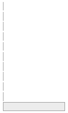

0  
(0.0%)

Distribution  
[factor]

1. TUMBLR  
2. PROLIFIC

78 (19.6%)  
320 (80.4%)

0  
(0.0%)

Assigned.Block  
[factor]

1. 1  
2. 2  
3. 3  
4. 4  
5. 5  
6. 6

135 (33.9%)  
52 (13.1%)  
52 (13.1%)  
54 (13.6%)  
53 (13.3%)  
52 (13.1%)

0  
(0.0%)

EndState  
[factor]

1. COMPLETE

388 (100.0%)

10  
(2.5%)

Sample  
[factor]

1. TUMBLR  
2. DATACOLLAR  
3. BLUECOLLAR  
4. GENERAL

78 (19.6%)  
20 ( 5.0%)  
20 ( 5.0%)  
280 (70.4%)

0  
(0.0%)

Study  
[factor]

1. Study1  
2. Study2  
3. Study3  
4. Study0

78 (19.6%)  
240 (60.3%)  
40 (10.1%)  
40 (10.1%)

0  
(0.0%)

duration.sec  
[numeric]

Mean (sd) : 2653.7 (1463.1)  
min < med < max:  
653 < 2290.5 < 13654  
IQR (CV) : 1525.2 (0.6)

379 distinct values

0  
(0.0%)

duration.min  
[numeric]

Mean (sd) : 44.2 (24.4)  
min < med < max:  
10.9 < 38.2 < 227.6  
IQR (CV) : 25.4 (0.6)

379 distinct values

0  
(0.0%)

D_gender_collapsed  
[factor]

1. female  
2. male  
3. other

196 (49.2%)  
145 (36.4%)  
57 (14.3%)

0  
(0.0%)

D_gender  
[factor]

1. Female  
2. Male  
3. Non-binary / third gender  
4. Prefer not to say  
5. Prefer to self-describe

196 (49.2%)  
145 (36.4%)  
40 (10.1%)  
3 ( 0.8%)  
14 ( 3.5%)

0  
(0.0%)

D_gender_4_TEXT  
[character]

1. genderqueer  
2. Agender  
3. gender fluid  
4. genderqueer (dislike term  
5. genderqueer trans man  
6. Genderqueer wlw  
7. genderqueer woman  
8. My sex is female, but I d  
9. queer  
10. She/They  
[ 3 others ]

2 (14.3%)  
1 ( 7.1%)  
1 ( 7.1%)  
1 ( 7.1%)  
1 ( 7.1%)  
1 ( 7.1%)  
1 ( 7.1%)  
1 ( 7.1%)  
1 ( 7.1%)  
1 ( 7.1%)  
3 (21.4%)

384  
(96.5%)

D_race  
[character]

1. White or Caucasian  
2. Black or African American  
3. Asian  
4. Other  
5. White or Caucasian,Asian  
6. White or Caucasian,Black  
7. American Indian/Native Am  
8. White or Caucasian,Americ  
9. White or Caucasian,Other  
10. Prefer not to say  
[ 5 others ]

268 (67.3%)  
44 (11.1%)  
40 (10.1%)  
11 ( 2.8%)  
9 ( 2.3%)  
5 ( 1.3%)  
4 ( 1.0%)  
4 ( 1.0%)  
4 ( 1.0%)  
3 ( 0.8%)  
6 ( 1.5%)

0  
(0.0%)

D_education_collapsed  
[factor]

1. hs_or_less  
2. ugrad  
3. grad

49 (12.3%)  
278 (69.8%)  
71 (17.8%)

0  
(0.0%)

D_education  
[factor]

1. NA  
2. some high school or less  
3. high school diploma or GE  
4. some college  
5. associates or technical d  
6. undergradudate degree  
7. graduate or professional

0 ( 0.0%)  
7 ( 1.8%)  
42 (10.6%)  
74 (18.6%)  
46 (11.6%)  
158 (39.7%)  
71 (17.8%)

0  
(0.0%)

D_employmentStatus  
[factor]

1. A homemaker or stay-at-ho  
2. Other  
3. Retired  
4. Student  
5. Unemployed and looking fo  
6. Working full-time  
7. Working part-time

15 ( 3.8%)  
16 ( 4.0%)  
9 ( 2.3%)  
33 ( 8.3%)  
56 (14.1%)  
205 (51.5%)  
64 (16.1%)

0  
(0.0%)

D_income  
[factor]

1. Prefer not to say  
2. Less than $25,000  
3. $25,000-$49,999  
4. $50,000-$74,999  
5. $75,000-$99,999  
6. $100,000-$149,999  
7. $150,000 or more

16 ( 4.0%)  
64 (16.1%)  
85 (21.4%)  
94 (23.6%)  
47 (11.8%)  
60 (15.1%)  
32 ( 8.0%)

0  
(0.0%)

D_work_detail  
[character]

1. Unemployed  
2. N/A  
3. Student  
4. homemaker  
5. retired  
6. graphic designer  
7. IT  
8. Manager  
9. n/a  
10. Artist  
[ 338 others ]

10 ( 2.5%)  
6 ( 1.5%)  
5 ( 1.3%)  
4 ( 1.0%)  
4 ( 1.0%)  
3 ( 0.8%)  
3 ( 0.8%)  
3 ( 0.8%)  
3 ( 0.8%)  
2 ( 0.5%)  
353 (89.1%)

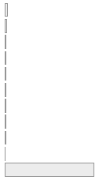

2  
(0.5%)

D_zipcode  
[character]

1. 30019  
2. 11105  
3. 11213  
4. 11581  
5. 20149  
6. 27858  
7. 28645  
8. 32607  
9. 37917  
10. 60615  
[ 368 others ]

3 ( 0.8%)  
2 ( 0.5%)  
2 ( 0.5%)  
2 ( 0.5%)  
2 ( 0.5%)  
2 ( 0.5%)  
2 ( 0.5%)  
2 ( 0.5%)  
2 ( 0.5%)  
2 ( 0.5%)  
374 (94.7%)

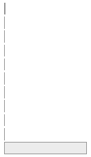

3  
(0.8%)

D_age  
[factor]

1. 18-24  
2. 25-34  
3. 35-44  
4. 45-54  
5. 55-64  
6. 65+ years

82 (20.6%)  
148 (37.2%)  
76 (19.1%)  
65 (16.3%)  
22 ( 5.5%)  
5 ( 1.3%)

0  
(0.0%)

D_politicalParty  
[factor]

1. Democrat  
2. Other  
3. No preference  
4. Independent  
5. Republican

189 (48.7%)  
31 ( 8.0%)  
12 ( 3.1%)  
111 (28.6%)  
45 (11.6%)

10  
(2.5%)

D_politicalParty_OTHER  
[character]

1. Socialist  
2. leftist  
3. socialist  
4. Anarchist  
5. Liberal  
6. Progressive  
7. A progressive who must vo  
8. Democratic Socialist  
9. Freedom and peace party  
10. Green  
[ 11 others ]

4 (12.9%)  
3 ( 9.7%)  
3 ( 9.7%)  
2 ( 6.5%)  
2 ( 6.5%)  
2 ( 6.5%)  
1 ( 3.2%)  
1 ( 3.2%)  
1 ( 3.2%)  
1 ( 3.2%)  
11 (35.5%)

367  
(92.2%)

D_politicsSocial  
[numeric]

Mean (sd) : 29.1 (27.9)  
min < med < max:  
0 < 23 < 100  
IQR (CV) : 48 (1)

75 distinct values

10  
(2.5%)

D_politicsFiscal  
[numeric]

Mean (sd) : 35.2 (29.1)  
min < med < max:  
0 < 35 < 100  
IQR (CV) : 43 (0.8)

79 distinct values

10  
(2.5%)

SCREEN_workMethod  
[character]

1. btwn-50-75  
2. btwn25-50  
3. less-25  
4. more-75

56 (14.1%)  
28 ( 7.0%)  
64 (16.1%)  
250 (62.8%)

0  
(0.0%)

SCREEN_workFunction  
[character]

1. other  
2. Operations  
3. Education-Professional  
4. Design-Creative  
5. IT  
6. Data-Analysis  
7. Research  
8. Healthcare-Professional  
9. Administration-PersonalAs  
10. Sales-Business-Developmen  
[ 78 others ]

88 (22.1%)  
29 ( 7.3%)  
26 ( 6.5%)  
23 ( 5.8%)  
20 ( 5.0%)  
19 ( 4.8%)  
19 ( 4.8%)  
16 ( 4.0%)  
15 ( 3.8%)  
15 ( 3.8%)  
128 (32.2%)

0  
(0.0%)

SCREEN_workFunction_TEXT  
[character]

1. N/A  
2. Unemployed  
3. Student  
4. n/a  
5. retired  
6. unemployed  
7. Logistics  
8. Not applicable  
9. Alternative Health  
10. Business services  
[ 56 others ]

7 ( 7.8%)  
6 ( 6.7%)  
5 ( 5.6%)  
4 ( 4.4%)  
3 ( 3.3%)  
3 ( 3.3%)  
2 ( 2.2%)  
2 ( 2.2%)  
1 ( 1.1%)  
1 ( 1.1%)  
56 (62.2%)

308  
(77.4%)

SCREEN_socialMedia  
[character]

1. Twitter,Reddit,LinkedIn  
2. Facebook,Instagram,Reddit  
3. Facebook,Twitter,Instagra  
4. Facebook,Twitter,Youtube,  
5. Facebook,Twitter,Youtube,  
6. Facebook,Twitter,Reddit,L  
7. Facebook,Twitter,Youtube,  
8. Facebook,Instagram,Reddit  
9. Facebook,Reddit,LinkedIn  
10. Facebook,Twitter,Instagra  
[ 210 others ]

10 ( 2.5%)  
9 ( 2.3%)  
9 ( 2.3%)  
8 ( 2.0%)  
8 ( 2.0%)  
7 ( 1.8%)  
7 ( 1.8%)  
6 ( 1.5%)  
6 ( 1.5%)  
6 ( 1.5%)  
322 (80.9%)

0  
(0.0%)

SCREEN_socialMedia_TEXT  
[character]

1. Discord  
2. Bluesky  
3. 4chan  
4. alt tech, to avoid exactl  
5. blue sky  
6. discord  
7. Livejournal  
8. mastedons,telegram  
9. Monster, GlassDoor  
10. nextdoor  
[ 8 others ]

5 (21.7%)  
2 ( 8.7%)  
1 ( 4.3%)  
1 ( 4.3%)  
1 ( 4.3%)  
1 ( 4.3%)  
1 ( 4.3%)  
1 ( 4.3%)  
1 ( 4.3%)  
1 ( 4.3%)  
8 (34.8%)

375  
(94.2%)

PLATFORM  
[factor]

1. Facebook  
2. Instagram  
3. LinkedIn  
4. Tumblr  
5. Twitter/X

102 (25.6%)  
115 (28.9%)  
8 ( 2.0%)  
75 (18.8%)  
98 (24.6%)

0  
(0.0%)

## 1.2 GRAPH/TRIAL-LEVEL

```r
dfSummary(df_graphs_all,  # %>% select(PID, duration.min, Distribution, Assigned.Block, PLATFORM,
                      #       contains("D_"), Prolific.Name:Study, contains("SCREEN_")),
          headings = TRUE,
          plain.ascii  = FALSE,
          style        = 'grid',
          graph.magnif = 0.85,
          varnumbers = FALSE,
          valid.col    = FALSE,
          tmp.img.dir  = "/tmp")
```

### 1.2.1 Data Frame Summary

#### 1.2.1.1 df_graphs_all

**Dimensions:** 2190 x 34  
**Duplicates:** 0

Variable

Stats / Values

Freqs (% of Valid)

Graph

Missing

PID  
[factor]

1. R_11XUYk3OpC3HJPM  
2. R_133GgyRbPsqfxPD  
3. R_18Mwg4NFTa8GyAh  
4. R_1A0uAWls6AhmTfr  
5. R_1aUA7MBz4XYLbkl  
6. R_1azgETg5gjYGzUf  
7. R_1Bc6WwJjiC9VBVn  
8. R_1Cq1wvlMciQUHh8  
9. R_1D2krAejiiSE3Ln  
10. R_1dz1Y8zwrsbEbB6  
[ 388 others ]

5 ( 0.2%)  
5 ( 0.2%)  
5 ( 0.2%)  
5 ( 0.2%)  
5 ( 0.2%)  
5 ( 0.2%)  
5 ( 0.2%)  
5 ( 0.2%)  
5 ( 0.2%)  
5 ( 0.2%)  
2140 (97.7%)

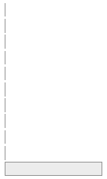

0  
(0.0%)

Assigned.Block  
[factor]

1. 1  
2. 2  
3. 3  
4. 4  
5. 5  
6. 6

875 (40.0%)  
260 (11.9%)  
260 (11.9%)  
270 (12.3%)  
265 (12.1%)  
260 (11.9%)

0  
(0.0%)

Study  
[factor]

1. Study1  
2. Study2  
3. Study0  
4. Study3

390 (17.8%)  
1200 (54.8%)  
200 ( 9.1%)  
400 (18.3%)

0  
(0.0%)

Sample  
[factor]

1. TUMBLR  
2. DATACOLLAR  
3. BLUECOLLAR  
4. GENERAL

390 (17.8%)  
100 ( 4.6%)  
100 ( 4.6%)  
1600 (73.1%)

0  
(0.0%)

D_politicsSocial  
[numeric]

Mean (sd) : 30.6 (28.8)  
min < med < max:  
0 < 24 < 100  
IQR (CV) : 47.2 (0.9)

75 distinct values

50  
(2.3%)

D_politicsFiscal  
[numeric]

Mean (sd) : 36.2 (29.5)  
min < med < max:  
0 < 36 < 100  
IQR (CV) : 47.2 (0.8)

79 distinct values

50  
(2.3%)

STIMULUS_CATEGORY  
[factor]

1. F  
2. D  
3. C  
4. B  
5. A

438 (20.0%)  
438 (20.0%)  
438 (20.0%)  
438 (20.0%)  
438 (20.0%)

0  
(0.0%)

STIMULUS  
[factor]

1. B0-0  
2. B1-1  
3. B1-2  
4. B1-3  
5. B1-4  
6. B2-1  
7. B2-2  
8. B2-3  
9. B2-4  
10. B3-1  
[ 15 others ]

438 (20.0%)  
175 ( 8.0%)  
175 ( 8.0%)  
175 ( 8.0%)  
175 ( 8.0%)  
52 ( 2.4%)  
52 ( 2.4%)  
52 ( 2.4%)  
52 ( 2.4%)  
52 ( 2.4%)  
792 (36.2%)

0  
(0.0%)

BLOCK  
[factor]

1. B0  
2. B1  
3. B2  
4. B3  
5. B4  
6. B5  
7. B6

438 (20.0%)  
700 (32.0%)  
208 ( 9.5%)  
208 ( 9.5%)  
216 ( 9.9%)  
212 ( 9.7%)  
208 ( 9.5%)

0  
(0.0%)

ENCOUNTER  
[factor]

1. scroll  
2. engage

930 (42.5%)  
1260 (57.5%)

0  
(0.0%)

ID  
[factor]

1. individual  
2. organization  
3. education  
4. business  
5. news  
6. political

258 (11.8%)  
149 ( 6.8%)  
524 (23.9%)  
436 (19.9%)  
426 (19.5%)  
397 (18.1%)

0  
(0.0%)

AGE  
[factor]

1. boomer  
2. gen-x  
3. millennial  
4. gen-z

228 (10.4%)  
901 (41.1%)  
875 (40.0%)  
186 ( 8.5%)

0  
(0.0%)

GENDER  
[factor]

1. Other  
2. Female  
3. Male

134 ( 6.1%)  
740 (33.8%)  
1316 (60.1%)

0  
(0.0%)

ID_CONF  
[numeric]

Mean (sd) : 56.6 (25)  
min < med < max:  
0 < 60 < 100  
IQR (CV) : 36 (0.4)

101 distinct values

0  
(0.0%)

AGE_CONF  
[numeric]

Mean (sd) : 54.9 (23.3)  
min < med < max:  
0 < 58 < 100  
IQR (CV) : 33 (0.4)

101 distinct values

0  
(0.0%)

GENDER_CONF  
[numeric]

Mean (sd) : 50.5 (25.5)  
min < med < max:  
0 < 51 < 100  
IQR (CV) : 38 (0.5)

101 distinct values

0  
(0.0%)

DESIGN  
[numeric]

Mean (sd) : 47.2 (28.2)  
min < med < max:  
0 < 44 < 100  
IQR (CV) : 45 (0.6)

101 distinct values

0  
(0.0%)

DATA  
[numeric]

Mean (sd) : 42.4 (27.4)  
min < med < max:  
0 < 39 < 100  
IQR (CV) : 44 (0.6)

101 distinct values

0  
(0.0%)

POLITICS  
[numeric]

Mean (sd) : 46.6 (19.5)  
min < med < max:  
0 < 50 < 100  
IQR (CV) : 18 (0.4)

100 distinct values

0  
(0.0%)

ALIGN  
[numeric]

Mean (sd) : 53 (18.9)  
min < med < max:  
0 < 51 < 100  
IQR (CV) : 17 (0.4)

101 distinct values

0  
(0.0%)

TRUST  
[numeric]

Mean (sd) : 58.2 (19.5)  
min < med < max:  
0 < 58 < 100  
IQR (CV) : 20 (0.3)

99 distinct values

0  
(0.0%)

BEAUTY  
[numeric]

Mean (sd) : 49.2 (28.8)  
min < med < max:  
0 < 54 < 100  
IQR (CV) : 47 (0.6)

101 distinct values

0  
(0.0%)

INTENT  
[numeric]

Mean (sd) : 41.3 (31.5)  
min < med < max:  
0 < 35 < 100  
IQR (CV) : 56 (0.8)

101 distinct values

0  
(0.0%)

ID_CONF_z  
[numeric]

Mean (sd) : 0 (1)  
min < med < max:  
-2.6 < 0.2 < 1.7  
IQR (CV) : 1.3 (-2.343242e+16)

242 distinct values

0  
(0.0%)

AGE_CONF_z  
[numeric]

Mean (sd) : 0 (1)  
min < med < max:  
-2.9 < 0.1 < 1.9  
IQR (CV) : 1.3 (-9.566842e+15)

229 distinct values

0  
(0.0%)

GENDER_CONF_z  
[numeric]

Mean (sd) : 0 (1)  
min < med < max:  
-2.2 < 0.1 < 1.9  
IQR (CV) : 1.5 (1.160116e+16)

234 distinct values

0  
(0.0%)

DESIGN_z  
[numeric]

Mean (sd) : 0 (1)  
min < med < max:  
-1.7 < -0.1 < 2.1  
IQR (CV) : 1.6 (1.427101e+16)

252 distinct values

0  
(0.0%)

DATA_z  
[numeric]

Mean (sd) : 0 (1)  
min < med < max:  
-1.6 < -0.1 < 2.5  
IQR (CV) : 1.6 (1.415556e+16)

257 distinct values

0  
(0.0%)

POLITICS_z  
[numeric]

Mean (sd) : 0 (1)  
min < med < max:  
-2.5 < 0.1 < 2.8  
IQR (CV) : 1 (-7.53054e+15)

233 distinct values

0  
(0.0%)

ALIGN_z  
[numeric]

Mean (sd) : 0 (1)  
min < med < max:  
-2.9 < -0.1 < 2.6  
IQR (CV) : 1 (-6.62955e+15)

230 distinct values

0  
(0.0%)

TRUST_z  
[numeric]

Mean (sd) : 0 (1)  
min < med < max:  
-3.1 < 0 < 2.2  
IQR (CV) : 1.1 (-1.775459e+16)

232 distinct values

0  
(0.0%)

BEAUTY_z  
[numeric]

Mean (sd) : 0 (1)  
min < med < max:  
-1.9 < 0.1 < 1.8  
IQR (CV) : 1.6 (1.219112e+16)

248 distinct values

0  
(0.0%)

INTENT_z  
[numeric]

Mean (sd) : 0 (1)  
min < med < max:  
-1.5 < -0.2 < 1.9  
IQR (CV) : 1.8 (7.19836e+16)

256 distinct values

0  
(0.0%)

TIME  
[character]

1. POST  
2. PRE

200 ( 9.1%)  
1990 (90.9%)

0  
(0.0%)